# Análise de personalidade de consumidores

## Discussão inicial

No contexto do negócio, a análise de queixas de consumidores é essencial para entender a satisfação dos clientes e identificar pontos críticos que impactam a experiência do usuário. No [conjunto de dados](https://www.kaggle.com/datasets/imakash3011/customer-personality-analysis/data) utilizado, a variável "Complain" indica se um cliente apresentou uma reclamação à empresa, o que pode fornecer insights valiosos sobre o comportamento e as expectativas dos consumidores.

A relevância dessa análise para a empresa reside na possibilidade de identificar padrões e tendências, podendo determinar se certas características dos clientes (como idade, nível de renda, hábitos de consumo) estão correlacionadas com maior propensão a registrar reclamações.

Por meio da análise, também é possível melhorar a retenção de clientes, tendo em vista que clientes insatisfeitos são mais propensos a abandonar a marca, e realizar a segmentação de clientes, permitindo direcionar ações específicas para cada segmento, como oferecer suporte diferenciado para clientes com maior risco de insatisfação.

O dataset também inclui variáveis sobre campanhas aceitas pelos clientes (AcceptedCmpX) e o engajamento em compras. Ao cruzar essas informações com as reclamações, a empresa pode entender se determinadas campanhas ou produtos geram insatisfação.

## Bibliotecas

```python
import pandas as pd
import seaborn as sns
import matplotlib.pyplot as plt
import numpy as np


from sklearn.model_selection import train_test_split
from sklearn.preprocessing import StandardScaler
from sklearn.ensemble import RandomForestClassifier
from sklearn.linear_model import LogisticRegression
from sklearn.tree import DecisionTreeClassifier
from sklearn.metrics import classification_report, confusion_matrix, roc_auc_score
from imblearn.over_sampling import SMOTE

sns.set_theme(style="whitegrid", palette="Set2")
```

## Leitura dos dados

```python
df = pd.read_csv("marketing_campaign.csv", sep="\t")
df.head()
```

|  | ID | Year_Birth | Education | Marital_Status | Income | Kidhome | Teenhome | Dt_Customer | Recency | MntWines | ... | NumWebVisitsMonth | AcceptedCmp3 | AcceptedCmp4 | AcceptedCmp5 | AcceptedCmp1 | AcceptedCmp2 | Complain | Z_CostContact | Z_Revenue | Response |
| --- | --- | --- | --- | --- | --- | --- | --- | --- | --- | --- | --- | --- | --- | --- | --- | --- | --- | --- | --- | --- | --- |
| 0 | 5524 | 1957 | Graduation | Single | 58138.0 | 0 | 0 | 04-09-2012 | 58 | 635 | ... | 7 | 0 | 0 | 0 | 0 | 0 | 0 | 3 | 11 | 1 |
| 1 | 2174 | 1954 | Graduation | Single | 46344.0 | 1 | 1 | 08-03-2014 | 38 | 11 | ... | 5 | 0 | 0 | 0 | 0 | 0 | 0 | 3 | 11 | 0 |
| 2 | 4141 | 1965 | Graduation | Together | 71613.0 | 0 | 0 | 21-08-2013 | 26 | 426 | ... | 4 | 0 | 0 | 0 | 0 | 0 | 0 | 3 | 11 | 0 |
| 3 | 6182 | 1984 | Graduation | Together | 26646.0 | 1 | 0 | 10-02-2014 | 26 | 11 | ... | 6 | 0 | 0 | 0 | 0 | 0 | 0 | 3 | 11 | 0 |
| 4 | 5324 | 1981 | PhD | Married | 58293.0 | 1 | 0 | 19-01-2014 | 94 | 173 | ... | 5 | 0 | 0 | 0 | 0 | 0 | 0 | 3 | 11 | 0 |

5 rows × 29 columns

```python
len(df["ID"].unique())
```

```
2240
```

```python
display(df.info())
display(df.describe())
```

```
<class 'pandas.core.frame.DataFrame'>
RangeIndex: 2240 entries, 0 to 2239
Data columns (total 29 columns):
 #   Column               Non-Null Count  Dtype
---  ------               --------------  -----
 0   ID                   2240 non-null   int64
 1   Year_Birth           2240 non-null   int64
 2   Education            2240 non-null   object
 3   Marital_Status       2240 non-null   object
 4   Income               2216 non-null   float64
 5   Kidhome              2240 non-null   int64
 6   Teenhome             2240 non-null   int64
 7   Dt_Customer          2240 non-null   object
 8   Recency              2240 non-null   int64
 9   MntWines             2240 non-null   int64
```

[output cut: 21 more lines]

```
None
```

|  | ID | Year_Birth | Income | Kidhome | Teenhome | Recency | MntWines | MntFruits | MntMeatProducts | MntFishProducts | ... | NumWebVisitsMonth | AcceptedCmp3 | AcceptedCmp4 | AcceptedCmp5 | AcceptedCmp1 | AcceptedCmp2 | Complain | Z_CostContact | Z_Revenue | Response |
| --- | --- | --- | --- | --- | --- | --- | --- | --- | --- | --- | --- | --- | --- | --- | --- | --- | --- | --- | --- | --- | --- |
| count | 2240.000000 | 2240.000000 | 2216.000000 | 2240.000000 | 2240.000000 | 2240.000000 | 2240.000000 | 2240.000000 | 2240.000000 | 2240.000000 | ... | 2240.000000 | 2240.000000 | 2240.000000 | 2240.000000 | 2240.000000 | 2240.000000 | 2240.000000 | 2240.0 | 2240.0 | 2240.000000 |
| mean | 5592.159821 | 1968.805804 | 52247.251354 | 0.444196 | 0.506250 | 49.109375 | 303.935714 | 26.302232 | 166.950000 | 37.525446 | ... | 5.316518 | 0.072768 | 0.074554 | 0.072768 | 0.064286 | 0.013393 | 0.009375 | 3.0 | 11.0 | 0.149107 |
| std | 3246.662198 | 11.984069 | 25173.076661 | 0.538398 | 0.544538 | 28.962453 | 336.597393 | 39.773434 | 225.715373 | 54.628979 | ... | 2.426645 | 0.259813 | 0.262728 | 0.259813 | 0.245316 | 0.114976 | 0.096391 | 0.0 | 0.0 | 0.356274 |
| min | 0.000000 | 1893.000000 | 1730.000000 | 0.000000 | 0.000000 | 0.000000 | 0.000000 | 0.000000 | 0.000000 | 0.000000 | ... | 0.000000 | 0.000000 | 0.000000 | 0.000000 | 0.000000 | 0.000000 | 0.000000 | 3.0 | 11.0 | 0.000000 |
| 25% | 2828.250000 | 1959.000000 | 35303.000000 | 0.000000 | 0.000000 | 24.000000 | 23.750000 | 1.000000 | 16.000000 | 3.000000 | ... | 3.000000 | 0.000000 | 0.000000 | 0.000000 | 0.000000 | 0.000000 | 0.000000 | 3.0 | 11.0 | 0.000000 |
| 50% | 5458.500000 | 1970.000000 | 51381.500000 | 0.000000 | 0.000000 | 49.000000 | 173.500000 | 8.000000 | 67.000000 | 12.000000 | ... | 6.000000 | 0.000000 | 0.000000 | 0.000000 | 0.000000 | 0.000000 | 0.000000 | 3.0 | 11.0 | 0.000000 |
| 75% | 8427.750000 | 1977.000000 | 68522.000000 | 1.000000 | 1.000000 | 74.000000 | 504.250000 | 33.000000 | 232.000000 | 50.000000 | ... | 7.000000 | 0.000000 | 0.000000 | 0.000000 | 0.000000 | 0.000000 | 0.000000 | 3.0 | 11.0 | 0.000000 |
| max | 11191.000000 | 1996.000000 | 666666.000000 | 2.000000 | 2.000000 | 99.000000 | 1493.000000 | 199.000000 | 1725.000000 | 259.000000 | ... | 20.000000 | 1.000000 | 1.000000 | 1.000000 | 1.000000 | 1.000000 | 1.000000 | 3.0 | 11.0 | 1.000000 |

8 rows × 26 columns

### Significado das colunas

#### Pessoas

- ID: Identificador único do cliente
- Year_Birth: Ano de nascimento do cliente
- Education: Nível de escolaridade do cliente
- Marital_Status: Estado civil do cliente
- Income: Renda anual do domicílio do cliente
- Kidhome: Número de crianças no domicílio do cliente
- Teenhome: Número de adolescentes no domicílio do cliente
- Dt_Customer: Data de cadastro do cliente na empresa
- Recency: Número de dias desde a última compra do cliente
- Complain: 1 se o cliente fez uma reclamação nos últimos 2 anos, 0 caso contrário

#### Produtos

- MntWines: Valor gasto em vinhos nos últimos 2 anos
- MntFruits: Valor gasto em frutas nos últimos 2 anos
- MntMeatProducts: Valor gasto em carnes nos últimos 2 anos
- MntFishProducts: Valor gasto em peixes nos últimos 2 anos
- MntSweetProducts: Valor gasto em doces nos últimos 2 anos
- MntGoldProds: Valor gasto em produtos de ouro nos últimos 2 anos

#### Promoções

- NumDealsPurchases: Número de compras feitas com desconto
- AcceptedCmp1: 1 se o cliente aceitou a oferta na 1ª campanha, 0 caso contrário
- AcceptedCmp2: 1 se o cliente aceitou a oferta na 2ª campanha, 0 caso contrário
- AcceptedCmp3: 1 se o cliente aceitou a oferta na 3ª campanha, 0 caso contrário
- AcceptedCmp4: 1 se o cliente aceitou a oferta na 4ª campanha, 0 caso contrário
- AcceptedCmp5: 1 se o cliente aceitou a oferta na 5ª campanha, 0 caso contrário
- Response: 1 se o cliente aceitou a oferta na última campanha, 0 caso contrário

#### Local de Compra

- NumWebPurchases: Número de compras feitas pelo site da empresa
- NumCatalogPurchases: Número de compras feitas por catálogo
- NumStorePurchases: Número de compras feitas diretamente nas lojas físicas
- NumWebVisitsMonth: Número de visitas ao site da empresa no último mês

### Limpeza, formatação dos dados e feature engineering

```python
missing_values = df.isnull().sum()
print("Valores ausentes por coluna:\n", missing_values[missing_values > 0])
```

```
Valores ausentes por coluna:
 Income    24
dtype: int64
```

Como proporcionalmente há poucos valores ausentes para a coluna relativa aos salários ("Income"), é possível remover essas linhas para realizar o restante da análise:

```python
df = df.dropna()
print("Número  de linhas após remoção:", len(df))
missing_values = df.isnull().sum()
print("Valores ausentes por coluna:\n", missing_values[missing_values > 0])
```

```
Número  de linhas após remoção: 2216
Valores ausentes por coluna:
 Series([], dtype: int64)
```

```python
# Ajustando tipo da coluna Dt_Customer

df["Dt_Customer"] = pd.to_datetime(df["Dt_Customer"], format="%d-%m-%Y")
```

```python
df["Marital_Status"].value_counts()
```

```
Marital_Status
Married     857
Together    573
Single      471
Divorced    232
Widow        76
Alone         3
Absurd        2
YOLO          2
Name: count, dtype: int64
```

```python
df["Education"].value_counts()
```

```
Education
Graduation    1116
PhD            481
Master         365
2n Cycle       200
Basic           54
Name: count, dtype: int64
```

#### Feature enginnering (Baseado em [Customer Segmentation: Clustering](https://www.kaggle.com/code/karnikakapoor/customer-segmentation-clustering))

- Extração da variável "Age" a partir de "Year_Birth", indicando a idade do cliente com base no ano de nascimento.
- Criação da variável "Spent", que representa o total gasto pelo cliente em diversas categorias ao longo de dois anos.
- Criação da variável "Living_With" a partir de "Marital_Status", para identificar a situação de convivência dos clientes (por exemplo, casais que vivem juntos).
- Criação da variável "Children" para indicar o número total de crianças no domicílio, considerando tanto crianças pequenas quanto adolescentes.
- Para obter uma visão mais clara da composição familiar, criar a variável "Family_Size", indicando o tamanho da família.
- Criar a variável "Is_Parent" para indicar se o cliente é pai/mãe.
- Por fim, simplificar as categorias de "Education", agrupando-as em três categorias distintas.
- Remover variáveis redundantes.

```python
df["Age"] = 2024-df["Year_Birth"]

# Total gasto em vários itens

df["Spent"] = df["MntWines"] + df["MntFruits"] + df["MntMeatProducts"] + df["MntFishProducts"] + df["MntSweetProducts"] + df["MntGoldProds"]

# Derivando se pessoa vive só ou com mais pessoas
df["Living_With"] = df["Marital_Status"].replace({
    "Married": "Partner", "Together": "Partner",
    "Absurd": "Alone", "Widow": "Alone", "YOLO": "Alone",
    "Divorced": "Alone", "Single": "Alone"
})

# Total de crianças vivendo na casa
df["Children"] = df["Kidhome"] + df["Teenhome"]

# Número de membros vivendo na casa
df["Family_Size"] = df["Living_With"].replace({"Alone": 1, "Partner": 2}).infer_objects(copy=False) + df["Children"]

# Indicador se cliente é pai/mãe
df["Is_Parent"] = np.where(df["Children"] > 0, 1, 0)

# Segmentar educação em 3 níveis (básica, graduação e PhD)
df["Education"] = df["Education"].replace({
    "Basic": "Undergraduate", "2n Cycle": "Undergraduate",
    "Graduation": "Graduate", "Master": "Postgraduate",
    "PhD": "Postgraduate"
})

# Renomear colunas para clareza
df = df.rename(columns={
    "MntWines": "Wines", "MntFruits": "Fruits",
    "MntMeatProducts": "Meat", "MntFishProducts": "Fish",
    "MntSweetProducts": "Sweets", "MntGoldProds": "Gold"
})

# Dias desde registro do primeiro cliente
df["Days_Customer"] = (df["Dt_Customer"] - df["Dt_Customer"].min()).dt.days


# Remoção de features redundantes
to_drop = ["Marital_Status", "Dt_Customer", "Z_CostContact", "Z_Revenue", "Year_Birth", "ID"]
df = df.drop(to_drop, axis=1)
```

## Análise exploratória

```python
df["Complain"].value_counts()
```

```
Complain
0    2195
1      21
Name: count, dtype: int64
```

```python
df.columns
```

```
Index(['Education', 'Income', 'Kidhome', 'Teenhome', 'Recency', 'Wines',
       'Fruits', 'Meat', 'Fish', 'Sweets', 'Gold', 'NumDealsPurchases',
       'NumWebPurchases', 'NumCatalogPurchases', 'NumStorePurchases',
       'NumWebVisitsMonth', 'AcceptedCmp3', 'AcceptedCmp4', 'AcceptedCmp5',
       'AcceptedCmp1', 'AcceptedCmp2', 'Complain', 'Response', 'Age', 'Spent',
       'Living_With', 'Children', 'Family_Size', 'Is_Parent', 'Days_Customer'],
      dtype='object')
```

```python
df[df["Complain"] == 1]
```

|  | Education | Income | Kidhome | Teenhome | Recency | Wines | Fruits | Meat | Fish | Sweets | ... | AcceptedCmp2 | Complain | Response | Age | Spent | Living_With | Children | Family_Size | Is_Parent | Days_Customer |
| --- | --- | --- | --- | --- | --- | --- | --- | --- | --- | --- | --- | --- | --- | --- | --- | --- | --- | --- | --- | --- | --- |
| 78 | Undergraduate | 26326.0 | 0 | 0 | 12 | 1 | 0 | 5 | 0 | 3 | ... | 0 | 1 | 0 | 48 | 18 | Partner | 0 | 2 | 0 | 401 |
| 147 | Graduate | 38547.0 | 1 | 0 | 49 | 6 | 1 | 10 | 0 | 1 | ... | 0 | 1 | 0 | 43 | 22 | Partner | 1 | 3 | 1 | 394 |
| 192 | Undergraduate | 36640.0 | 1 | 0 | 99 | 15 | 6 | 8 | 7 | 4 | ... | 0 | 1 | 0 | 124 | 65 | Alone | 1 | 2 | 1 | 423 |
| 271 | Postgraduate | 31788.0 | 1 | 0 | 15 | 16 | 7 | 23 | 0 | 8 | ... | 0 | 1 | 0 | 41 | 60 | Alone | 1 | 2 | 1 | 598 |
| 355 | Graduate | 38643.0 | 1 | 1 | 45 | 22 | 2 | 14 | 0 | 1 | ... | 0 | 1 | 0 | 46 | 49 | Alone | 2 | 3 | 1 | 487 |
| 358 | Postgraduate | 65073.0 | 0 | 0 | 65 | 629 | 17 | 177 | 69 | 0 | ... | 0 | 1 | 0 | 81 | 900 | Partner | 0 | 2 | 0 | 386 |
| 590 | Postgraduate | 39684.0 | 1 | 0 | 41 | 19 | 0 | 35 | 6 | 4 | ... | 0 | 1 | 1 | 40 | 81 | Alone | 1 | 2 | 1 | 74 |
| 972 | Undergraduate | 15716.0 | 1 | 0 | 8 | 16 | 5 | 30 | 8 | 7 | ... | 0 | 1 | 0 | 36 | 92 | Partner | 1 | 3 | 1 | 105 |
| 1041 | Graduate | 38998.0 | 1 | 1 | 92 | 34 | 1 | 14 | 0 | 0 | ... | 0 | 1 | 0 | 70 | 54 | Partner | 2 | 4 | 1 | 96 |
| 1069 | Graduate | 67023.0 | 0 | 0 | 93 | 444 | 44 | 382 | 11 | 8 | ... | 0 | 1 | 0 | 46 | 906 | Partner | 0 | 2 | 0 | 582 |
| 1180 | Graduate | 48070.0 | 0 | 1 | 33 | 373 | 14 | 83 | 6 | 9 | ... | 0 | 1 | 0 | 74 | 504 | Partner | 1 | 3 | 1 | 167 |
| 1201 | Graduate | 58113.0 | 0 | 1 | 66 | 221 | 104 | 169 | 102 | 78 | ... | 0 | 1 | 0 | 65 | 758 | Partner | 1 | 3 | 1 | 179 |
| 1211 | Graduate | 65748.0 | 0 | 1 | 58 | 172 | 73 | 93 | 95 | 78 | ... | 0 | 1 | 0 | 69 | 545 | Partner | 1 | 3 | 1 | 259 |
| 1277 | Graduate | 40800.0 | 1 | 2 | 77 | 24 | 0 | 27 | 8 | 30 | ... | 0 | 1 | 0 | 60 | 99 | Partner | 3 | 5 | 1 | 155 |
| 1323 | Graduate | 37774.0 | 2 | 0 | 28 | 173 | 8 | 107 | 7 | 2 | ... | 0 | 1 | 1 | 47 | 473 | Alone | 2 | 3 | 1 | 35 |
| 1461 | Graduate | 57957.0 | 0 | 1 | 24 | 290 | 59 | 177 | 77 | 5 | ... | 0 | 1 | 0 | 65 | 637 | Partner | 1 | 3 | 1 | 385 |
| 1571 | Graduate | 38998.0 | 1 | 1 | 92 | 34 | 1 | 14 | 0 | 0 | ... | 0 | 1 | 0 | 70 | 54 | Partner | 2 | 4 | 1 | 96 |
| 1720 | Graduate | 17688.0 | 1 | 0 | 82 | 2 | 2 | 1 | 3 | 1 | ... | 0 | 1 | 0 | 45 | 11 | Partner | 1 | 3 | 1 | 167 |
| 1850 | Undergraduate | 83257.0 | 0 | 0 | 56 | 536 | 27 | 590 | 38 | 107 | ... | 0 | 1 | 1 | 29 | 1365 | Alone | 0 | 1 | 0 | 50 |
| 1924 | Graduate | 80982.0 | 1 | 1 | 48 | 505 | 137 | 401 | 104 | 22 | ... | 0 | 1 | 0 | 65 | 1191 | Alone | 2 | 3 | 1 | 162 |
| 2018 | Graduate | 22263.0 | 1 | 1 | 31 | 17 | 0 | 2 | 0 | 0 | ... | 0 | 1 | 0 | 73 | 21 | Alone | 2 | 3 | 1 | 608 |

21 rows × 30 columns

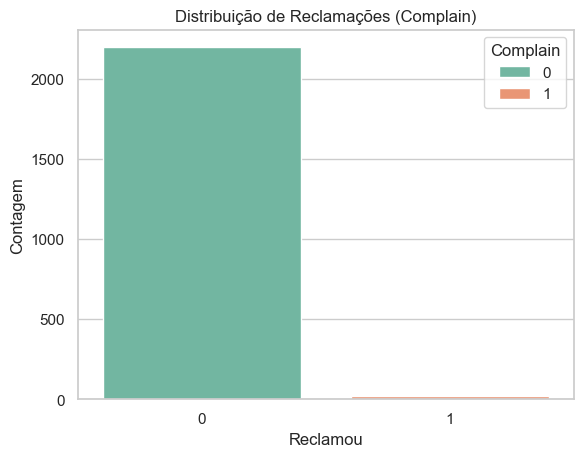

```python
sns.countplot(x=df["Complain"],  hue=df["Complain"])
plt.title("Distribuição de Reclamações (Complain)")
plt.xlabel("Reclamou")
plt.ylabel("Contagem")
plt.show()
```

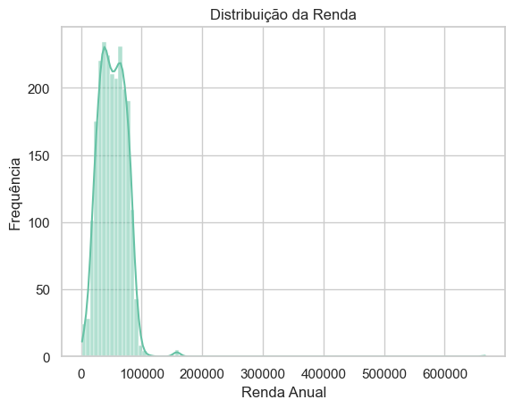

```python
sns.histplot(df["Income"], bins=100, kde=True)
plt.title("Distribuição da Renda")
plt.xlabel("Renda Anual")
plt.ylabel("Frequência")
plt.show()
```

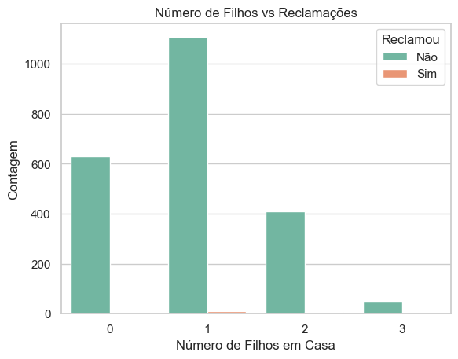

```python
sns.countplot(x=df["Children"], hue=df["Complain"])
plt.title("Número de Filhos vs Reclamações")
plt.xlabel("Número de Filhos em Casa")
plt.ylabel("Contagem")
plt.legend(title="Reclamou", labels=["Não", "Sim"])
plt.show()
```

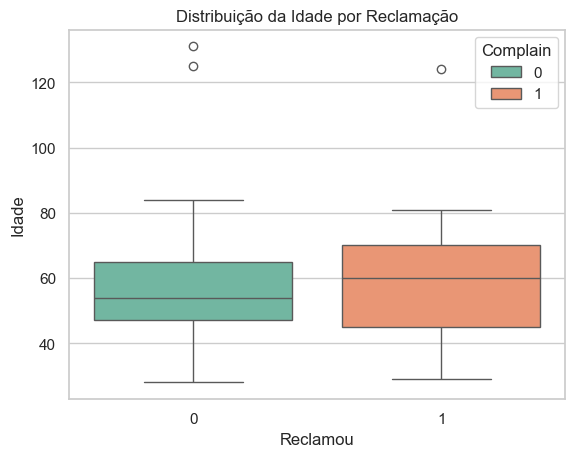

```python
sns.boxplot(x=df["Complain"], y=df["Age"], hue=df["Complain"])
plt.title("Distribuição da Idade por Reclamação")
plt.xlabel("Reclamou")
plt.ylabel("Idade")
plt.show()
```

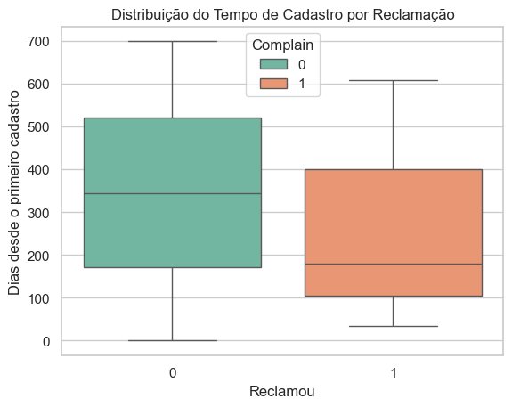

```python
sns.boxplot(x=df["Complain"], y=df["Days_Customer"], hue=df["Complain"])
plt.title("Distribuição do Tempo de Cadastro por Reclamação")
plt.xlabel("Reclamou")
plt.ylabel("Dias desde o primeiro cadastro")
plt.show()
```

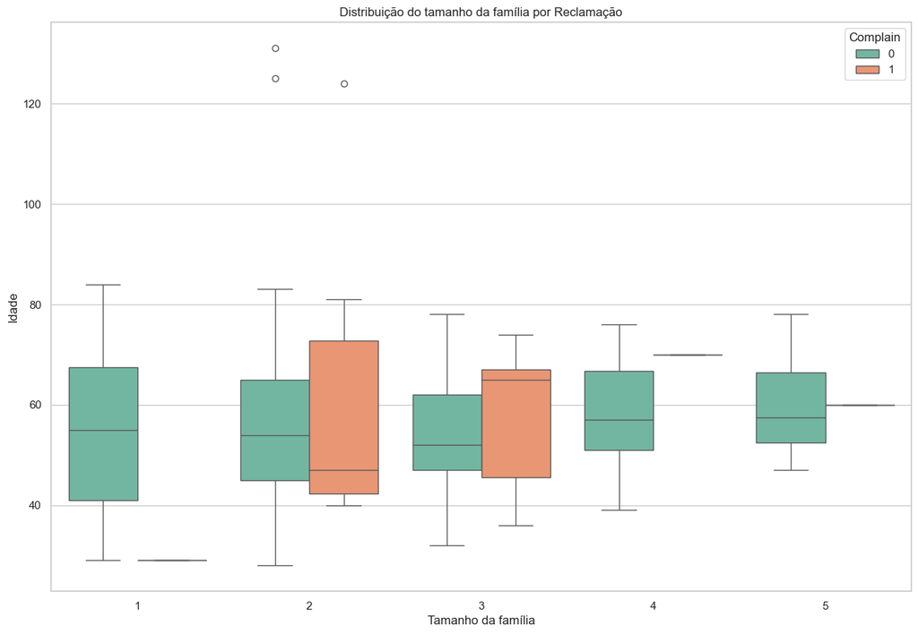

```python
plt.figure(figsize=(15,10))
sns.boxplot(x=df["Family_Size"], y=df["Age"], hue=df["Complain"])
plt.title("Distribuição do tamanho da família por Reclamação")
plt.ylabel("Idade")
plt.xlabel("Tamanho da família")
plt.show()
```

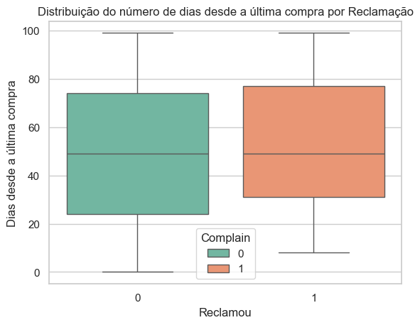

```python
sns.boxplot(x=df["Complain"], y=df["Recency"], hue=df["Complain"])
plt.title("Distribuição do número de dias desde a última compra por Reclamação")
plt.xlabel("Reclamou")
plt.ylabel("Dias desde a última compra")
plt.show()
```

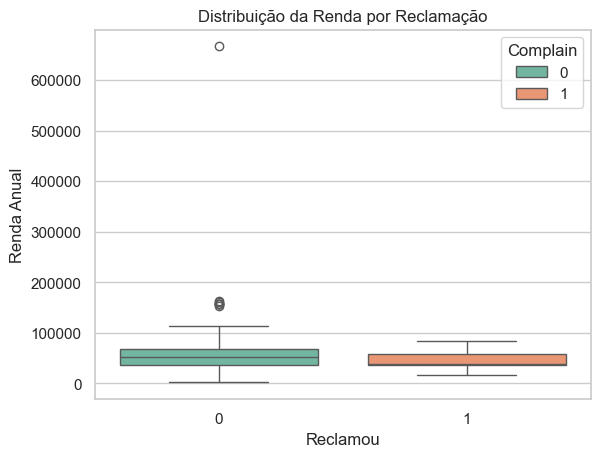

```python
sns.boxplot(x=df["Complain"], y=df["Income"], hue=df["Complain"])
plt.title("Distribuição da Renda por Reclamação")
plt.xlabel("Reclamou")
plt.ylabel("Renda Anual")
plt.show()
```

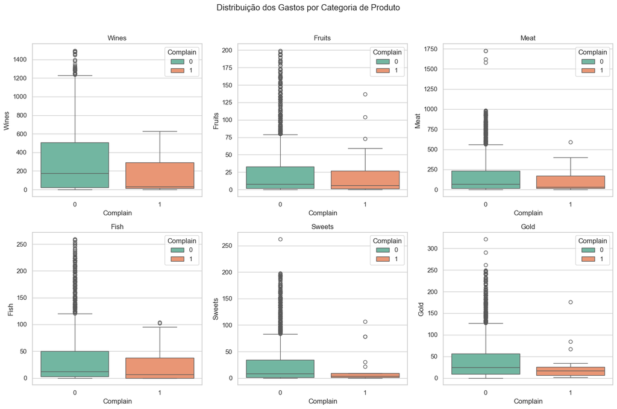

```python
fig, axes = plt.subplots(2, 3, figsize=(15, 10))
fig.suptitle("Distribuição dos Gastos por Categoria de Produto")

cols = ["Wines", "Fruits", "Meat", "Fish", "Sweets", "Gold"]

i, j = 0, 0
for col in cols:
    sns.boxplot(x=df["Complain"], y=df[col], ax=axes[i, j], hue=df["Complain"])
    axes[i, j].set_title(f"{col}")
    j += 1
    if j == 3:
        i += 1
        j = 0

plt.tight_layout(rect=[0, 0, 1, 0.96])
plt.show()
```

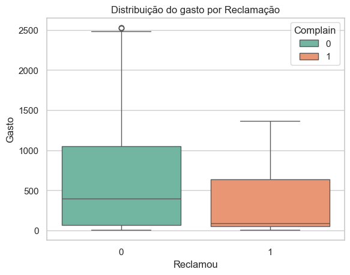

```python
sns.boxplot(x=df["Complain"], y=df["Spent"], hue=df["Complain"])
plt.title("Distribuição do gasto por Reclamação")
plt.xlabel("Reclamou")
plt.ylabel("Gasto")
plt.show()
```

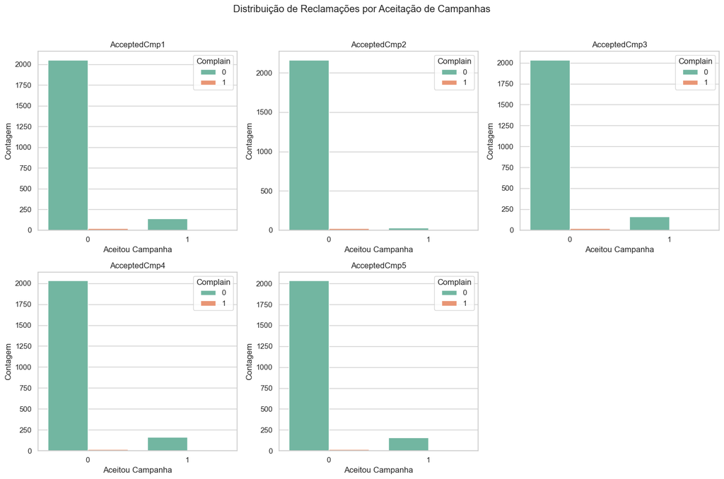

```python
fig, axes = plt.subplots(2, 3, figsize=(15, 10))
fig.suptitle("Distribuição de Reclamações por Aceitação de Campanhas")

cols = ["AcceptedCmp1", "AcceptedCmp2", "AcceptedCmp3", "AcceptedCmp4", "AcceptedCmp5"]

for idx, col in enumerate(cols):
    i, j = divmod(idx, 3)
    sns.countplot(x=df[col], hue=df["Complain"], ax=axes[i, j], palette="Set2")
    axes[i, j].set_title(f"{col}")
    axes[i, j].set_xlabel("Aceitou Campanha")
    axes[i, j].set_ylabel("Contagem")

fig.delaxes(axes[1, 2])

plt.tight_layout(rect=[0, 0, 1, 0.96])
plt.show()
```

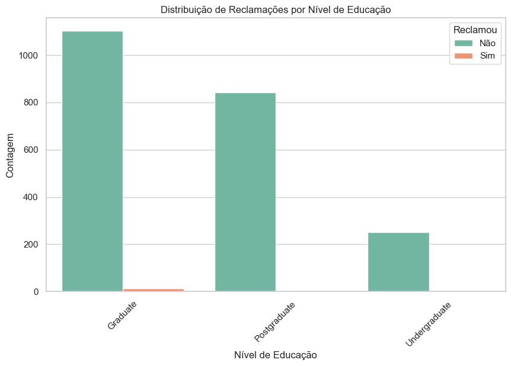

```python
plt.figure(figsize=(10, 6))
sns.countplot(x=df["Education"], hue=df["Complain"], palette="Set2")

plt.title("Distribuição de Reclamações por Nível de Educação")
plt.xlabel("Nível de Educação")
plt.ylabel("Contagem")
plt.xticks(rotation=45)
plt.legend(title="Reclamou", labels=["Não", "Sim"])
plt.show()
```

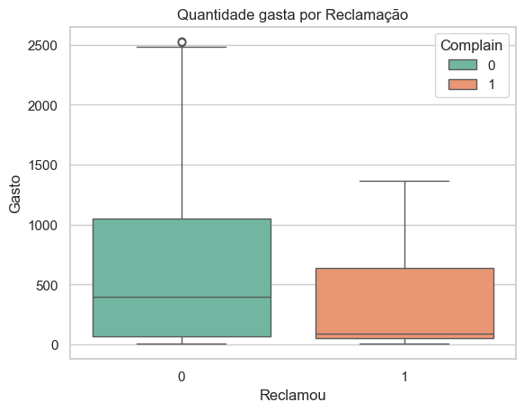

```python
sns.boxplot(x=df["Complain"], y=df["Spent"], hue=df["Complain"])
plt.title("Quantidade gasta por Reclamação")
plt.xlabel("Reclamou")
plt.ylabel("Gasto")
plt.show()
```

```python
df_encoded = pd.get_dummies(df, drop_first=True, dtype=int)  # Converte categorias em variáveis binárias
df_encoded
```

|  | Income | Kidhome | Teenhome | Recency | Wines | Fruits | Meat | Fish | Sweets | Gold | ... | Response | Age | Spent | Children | Family_Size | Is_Parent | Days_Customer | Education_Postgraduate | Education_Undergraduate | Living_With_Partner |
| --- | --- | --- | --- | --- | --- | --- | --- | --- | --- | --- | --- | --- | --- | --- | --- | --- | --- | --- | --- | --- | --- |
| 0 | 58138.0 | 0 | 0 | 58 | 635 | 88 | 546 | 172 | 88 | 88 | ... | 1 | 67 | 1617 | 0 | 1 | 0 | 36 | 0 | 0 | 0 |
| 1 | 46344.0 | 1 | 1 | 38 | 11 | 1 | 6 | 2 | 1 | 6 | ... | 0 | 70 | 27 | 2 | 3 | 1 | 586 | 0 | 0 | 0 |
| 2 | 71613.0 | 0 | 0 | 26 | 426 | 49 | 127 | 111 | 21 | 42 | ... | 0 | 59 | 776 | 0 | 2 | 0 | 387 | 0 | 0 | 1 |
| 3 | 26646.0 | 1 | 0 | 26 | 11 | 4 | 20 | 10 | 3 | 5 | ... | 0 | 40 | 53 | 1 | 3 | 1 | 560 | 0 | 0 | 1 |
| 4 | 58293.0 | 1 | 0 | 94 | 173 | 43 | 118 | 46 | 27 | 15 | ... | 0 | 43 | 422 | 1 | 3 | 1 | 538 | 1 | 0 | 1 |
| ... | ... | ... | ... | ... | ... | ... | ... | ... | ... | ... | ... | ... | ... | ... | ... | ... | ... | ... | ... | ... | ... |
| 2235 | 61223.0 | 0 | 1 | 46 | 709 | 43 | 182 | 42 | 118 | 247 | ... | 0 | 57 | 1341 | 1 | 3 | 1 | 318 | 0 | 0 | 1 |
| 2236 | 64014.0 | 2 | 1 | 56 | 406 | 0 | 30 | 0 | 0 | 8 | ... | 0 | 78 | 444 | 3 | 5 | 1 | 680 | 1 | 0 | 1 |
| 2237 | 56981.0 | 0 | 0 | 91 | 908 | 48 | 217 | 32 | 12 | 24 | ... | 0 | 43 | 1241 | 0 | 1 | 0 | 544 | 0 | 0 | 0 |
| 2238 | 69245.0 | 0 | 1 | 8 | 428 | 30 | 214 | 80 | 30 | 61 | ... | 0 | 68 | 843 | 1 | 3 | 1 | 543 | 1 | 0 | 1 |
| 2239 | 52869.0 | 1 | 1 | 40 | 84 | 3 | 61 | 2 | 1 | 21 | ... | 1 | 70 | 172 | 2 | 4 | 1 | 77 | 1 | 0 | 1 |

2216 rows × 31 columns

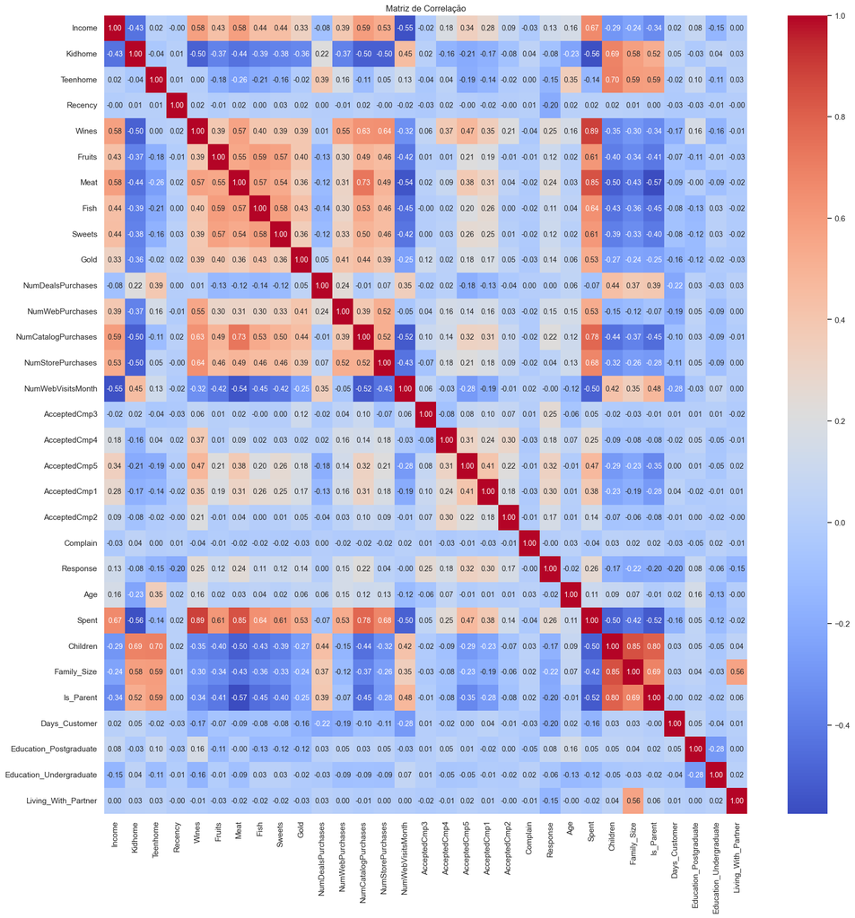

```python
plt.figure(figsize=(20,20))
corr_matrix = df_encoded.corr()
sns.heatmap(corr_matrix, annot=True, cmap="coolwarm", fmt=".2f", annot_kws={"size": 10})
plt.title("Matriz de Correlação")
plt.show()
```

```python
corr_pairs = corr_matrix.unstack().reset_index()
corr_pairs.columns = ["Feature_1", "Feature_2", "Correlation"]

corr_pairs = corr_pairs[corr_pairs["Feature_1"] != corr_pairs["Feature_2"]]

corr_pairs["Sorted_Features"] = corr_pairs.apply(lambda x: tuple(sorted([x["Feature_1"], x["Feature_2"]])), axis=1)
corr_pairs = corr_pairs.drop_duplicates(subset=["Sorted_Features"]).drop(columns=["Sorted_Features"])

top_10_corrs = corr_pairs.sort_values(by="Correlation", ascending=False).head(10)
print('10 maiores correlações:')
print(top_10_corrs[["Feature_1", "Feature_2", "Correlation"]])
```

```
10 maiores correlações:
               Feature_1            Feature_2  Correlation
147                Wines                Spent     0.893136
769             Children          Family_Size     0.849326
209                 Meat                Spent     0.845884
770             Children            Is_Parent     0.799805
395  NumCatalogPurchases                Spent     0.780482
198                 Meat  NumCatalogPurchases     0.734127
86              Teenhome             Children     0.697907
801          Family_Size            Is_Parent     0.691781
55               Kidhome             Children     0.687794
426    NumStorePurchases                Spent     0.675181
```

```python
bottom_10_corrs = corr_pairs.sort_values(by="Correlation").head(10)
print('10 menores correlações:')
print(bottom_10_corrs[["Feature_1", "Feature_2", "Correlation"]])
```

```
10 menores correlações:
               Feature_1            Feature_2  Correlation
212                 Meat            Is_Parent    -0.574931
54               Kidhome                Spent    -0.557899
14                Income    NumWebVisitsMonth    -0.553088
200                 Meat    NumWebVisitsMonth    -0.539484
739                Spent            Is_Parent    -0.522629
386  NumCatalogPurchases    NumWebVisitsMonth    -0.522004
210                 Meat             Children    -0.504545
43               Kidhome  NumCatalogPurchases    -0.504501
44               Kidhome    NumStorePurchases    -0.501349
737                Spent             Children    -0.500244
```

```python
corr_pairs[(corr_pairs["Feature_1"] == "Complain") | (corr_pairs["Feature_2"] == "Complain")].sort_values("Correlation")
```

|  | Feature_1 | Feature_2 | Correlation |
| --- | --- | --- | --- |
| 648 | Complain | Education_Postgraduate | -0.048101 |
| 144 | Wines | Complain | -0.039470 |
| 643 | Complain | Spent | -0.037428 |
| 647 | Complain | Days_Customer | -0.033279 |
| 299 | Gold | Complain | -0.031133 |
| 516 | AcceptedCmp4 | Complain | -0.027652 |
| 20 | Income | Complain | -0.027225 |
| 578 | AcceptedCmp1 | Complain | -0.025594 |
| 206 | Meat | Complain | -0.023782 |
| 268 | Sweets | Complain | -0.022641 |
| 237 | Fish | Complain | -0.021220 |
| 392 | NumCatalogPurchases | Complain | -0.020839 |
| 423 | NumStorePurchases | Complain | -0.016941 |
| 361 | NumWebPurchases | Complain | -0.016642 |
| 609 | AcceptedCmp2 | Complain | -0.011459 |
| 547 | AcceptedCmp5 | Complain | -0.009576 |
| 650 | Complain | Living_With_Partner | -0.005369 |
| 175 | Fruits | Complain | -0.005324 |
| 641 | Complain | Response | -0.002029 |
| 330 | NumDealsPurchases | Complain | 0.000497 |
| 82 | Teenhome | Complain | 0.003307 |
| 485 | AcceptedCmp3 | Complain | 0.008124 |
| 113 | Recency | Complain | 0.013637 |
| 454 | NumWebVisitsMonth | Complain | 0.019785 |
| 646 | Complain | Is_Parent | 0.020608 |
| 649 | Complain | Education_Undergraduate | 0.023291 |
| 645 | Complain | Family_Size | 0.023441 |
| 642 | Complain | Age | 0.030407 |
| 644 | Complain | Children | 0.031774 |
| 51 | Kidhome | Complain | 0.040978 |

### Insights iniciais:

#### Correlações

- Gastos em diferentes categorias de produtos (exemplo: Wines, Meat, Gold, etc.) tendem a ser altamente correlacionados entre si. Isso indica que clientes que gastam muito em uma categoria geralmente gastam bastante em outras também.
- Variáveis relativas ao número de compras (NumWebPurchases, NumStorePurchases, etc.) possui ter correlação entre si, mostrando padrões de compra.
- Idade ("Age") tem correlação positiva com número de adolescentes em casa ("Teenhome") e levemente positiva com algumas variáveis, como renda ("Income") e gasto com vinhos ("Wines"). Além disso, há correlação negativa com o número de crianças em casa.
- Renda ("Income") está positivamente correlacionada com gastos (Spent), mas também pode ter outliers influenciando a relação.
- Quanto maior o número de crianças em casa, menor o gasto e número de compras na loja e usando um catálogo.

## Remoção de outliers

```python
df = df[(df["Age"]<90)]
df = df[(df["Income"]<600000)]
print("Número de registro após remoções de outliers:", len(df))
```

```
Número de registro após remoções de outliers: 2212
```

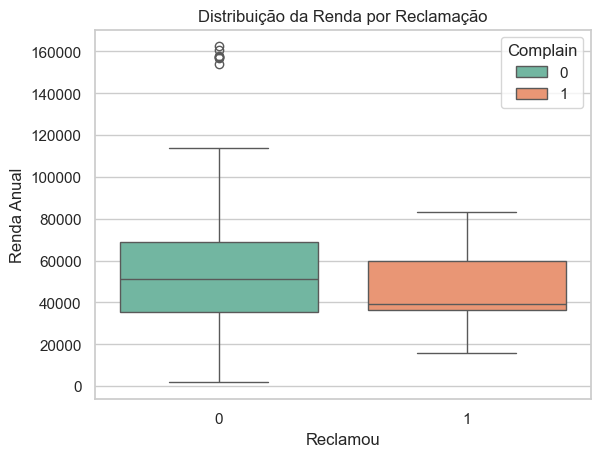

```python
sns.boxplot(x=df["Complain"], y=df["Income"], hue=df["Complain"])
plt.title("Distribuição da Renda por Reclamação")
plt.xlabel("Reclamou")
plt.ylabel("Renda Anual")
plt.show()
```

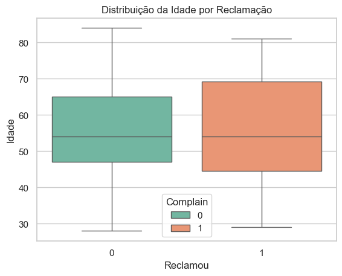

```python
sns.boxplot(x=df["Complain"], y=df["Age"], hue=df["Complain"])
plt.title("Distribuição da Idade por Reclamação")
plt.xlabel("Reclamou")
plt.ylabel("Idade")
plt.show()
```

## Escolha e treinamento dos modelos

### Modelos testados

- Regressão Logística: Modelo simples e amplamente utilizado para problemas de classificação binária. Sua principal vantagem é a interpretação fácil dos coeficientes, permitindo uma análise clara sobre a influência das variáveis independentes no resultado. No entanto, pode ter desempenho limitado em dados não lineares ou com interações complexas entre as variáveis.
- Árvore de Decisão: Modelo que divide os dados em segmentos baseados em regras de decisão, proporcionando uma explicação clara das variáveis mais importantes. Além disso, permite a modelagem de relações não lineares. Contudo, pode ser propenso ao overfitting se não for adequadamente podado e pode ser instável para pequenas variações nos dados.
- Random Forest: Um conjunto de várias árvores de decisão treinadas de forma independente, proporcionando maior robustez e desempenho em comparação a uma árvore única. Ideal para lidar com dados de alta dimensionalidade e complexidade, além de ser mais resistente ao overfitting. A desvantagem é a menor interpretabilidade, já que as árvores individuais ficam "embutidas" no modelo de conjunto.

### SMOTE

Como o dado apresenta uma variável alvo ("Complain") altamente desbalanceada (mais de 90% dos clientes não reclama), levando os modelos a ignorar a classe minoritária e simplesmente prever que ninguém reclama, o que não é útil, a técnica SMOTE (Synthetic Minority Over-sampling Technique) foi usada para aplicar oversampling.

Essa estratégia funciona por meio da geração de amostras sintéticas. Ou seja, em vez de simplesmente replicar as instâncias da classe minoritária (o que pode levar a overfitting), o SMOTE cria novas amostras artificiais selecionando aleatoriamente uma instância da classe minoritária e encontra seus vizinhos mais próximos no espaço de features e criando novos pontos interpolando entre essas instâncias.

```
Modelo: Logistic Regression
              precision    recall  f1-score   support

           0       0.72      0.82      0.77       451
           1       0.44      0.31      0.36       208

    accuracy                           0.66       659
   macro avg       0.58      0.57      0.57       659
weighted avg       0.63      0.66      0.64       659

AUC: 0.5651543578372846
--------------------------------------------------

Modelo: Decision Tree
              precision    recall  f1-score   support

           0       0.99      0.96      0.97       451
           1       0.91      0.97      0.94       208

    accuracy                           0.96       659
   macro avg       0.95      0.96      0.96       659
weighted avg       0.96      0.96      0.96       659

AUC: 0.9645126215248166
--------------------------------------------------

Modelo: Random Forest
              precision    recall  f1-score   support

           0       1.00      1.00      1.00       451
           1       1.00      0.99      0.99       208

    accuracy                           1.00       659
   macro avg       1.00      0.99      0.99       659
weighted avg       1.00      1.00      1.00       659

AUC: 0.9940836602421969
--------------------------------------------------
```

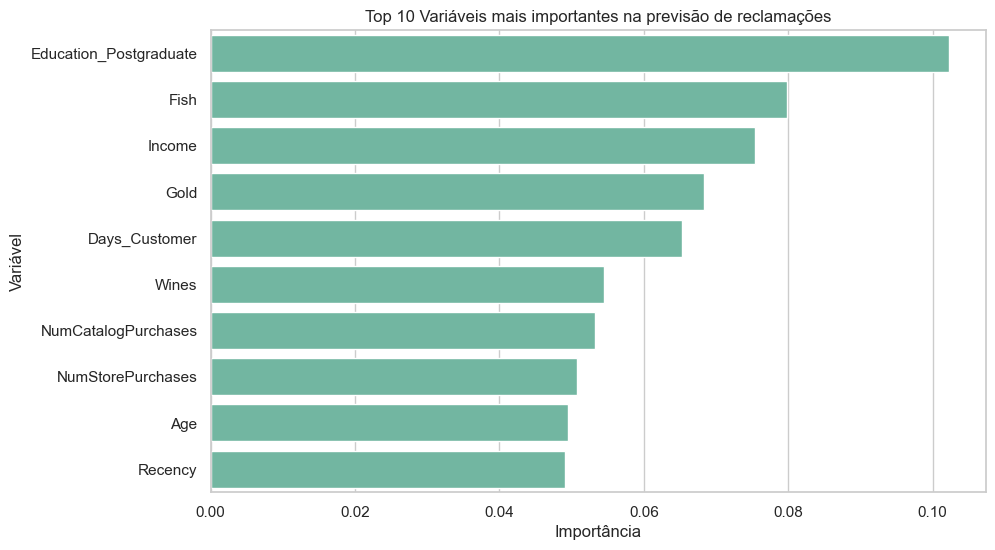

```python
X = df_encoded.drop(columns=["Complain"])
y = df_encoded["Complain"]

smote = SMOTE(sampling_strategy=0.5, random_state=42)
X_resampled, y_resampled = smote.fit_resample(X, y)

X_train, X_test, y_train, y_test = train_test_split(X_resampled, y_resampled, test_size=0.2, random_state=42)

models = {
    "Logistic Regression": LogisticRegression(),
    "Decision Tree": DecisionTreeClassifier(),
    "Random Forest": RandomForestClassifier()
}

for name, model in models.items():
    model.fit(X_train, y_train)
    y_pred = model.predict(X_test)
    print(f"\nModelo: {name}")
    print(classification_report(y_test, y_pred))
    print("AUC:", roc_auc_score(y_test, y_pred))
    print("-" * 50)

rf_model = RandomForestClassifier()
rf_model.fit(X_train, y_train)

feature_importance = pd.Series(rf_model.feature_importances_, index=X.columns)
feature_importance = feature_importance.sort_values(ascending=False)

plt.figure(figsize=(10, 6))
sns.barplot(x=feature_importance[:10], y=feature_importance.index[:10])
plt.title("Top 10 Variáveis mais importantes na previsão de reclamações")
plt.xlabel("Importância")
plt.ylabel("Variável")
plt.show()
```

## Conclusão

### Análise dos modelos

#### Performance

##### 1. Logistic Regression

Acurácia: 66% – Este modelo apresenta uma acurácia relativamente baixa, o que sugere que o modelo não está capturando bem a relação entre as variáveis independentes e o alvo.

Precision e Recall: Para a classe 0, o modelo tem boa precision (0.72) e recall (0.82), indicando que ele é mais eficaz em prever a classe 0 corretamente. No entanto, para a classe 1, a precision é baixa (0.44) e o recall é muito mais baixo (0.31), o que sugere que o modelo tem dificuldade em identificar corretamente a classe 1.

F1-Score: O f1-score para a classe 0 é razoável (0.77), mas para a classe 1, ele é bastante baixo (0.36), refletindo a baixa performance do modelo na classe minoritária.

##### 2. Decision Tree

Acurácia: 96% – O modelo de árvore de decisão apresenta um desempenho excelente com uma acurácia muito alta. Isso sugere que o modelo está capturando bem a relação entre as variáveis e o alvo.

Precision e Recall: Para a classe 0, o modelo tem uma precisão de 0.99 e um recall de 0.96, o que é excelente. Para a classe 1, a precisão e o recall também são altos (0.91 e 0.97, respectivamente), indicando que a árvore de decisão é eficaz em prever ambas as classes.

F1-Score: O f1-score é muito bom tanto para a classe 0 (0.97) quanto para a classe 1 (0.94), refletindo um bom equilíbrio entre precisão e recall para ambas as classes.

AUC: O AUC de 0.964 indica uma excelente capacidade de distinção entre as classes, sendo um ótimo resultado para esse modelo.

##### 3. Random Forest

Precision e Recall: Para ambas as classes, a precisão e o recall são 1.00 (precisão perfeita para a classe 0) e 0.99 (recall muito bom para a classe 1), o que é excelente. Isso sugere que o modelo está fazendo previsões muito precisas e consistentes.

F1-Score: O f1-score de 1.00 para a classe 0 e 0.99 para a classe 1 também reflete um equilíbrio perfeito entre precisão e recall.

AUC: O AUC de 0.994 indica uma capacidade quase perfeita de distinguir entre as classes, o que é uma excelente performance para o modelo.

### Referências

- [Synthetic Minority Over-sampling TEchnique (SMOTE)](https://medium.com/@corymaklin/synthetic-minority-over-sampling-technique-smote-7d419696b88c)